# 3’-isoform with clustQTL

Aaron Brooks

July 8, 2015

*Global detection of 3’-isoform QTLs with clustQTL.*

Analysis of all S288CxYJM (SxY) 3’-isoform data from Chenchen using clustQTL

## Preliminaries

Load files and required packages.

## Detect QTLs with clustQTL

Here is the code to compute isoform QTLs. This takes a day or two to run. To save time, I will load directly from file.

```r
pb <- txtProgressBar(min = 0, max = length(names(tx_3utr)), style = 3)
clust_qtls = lapply(seq(1,length(names(tx_3utr))), function(j) {
  setTxtProgressBar(pb, j)
  gene = names(tx_3utr)[j]
  o = try({
    #print(gene)
    x = subsetByOverlaps(cts,tx_3utr[gene])
    data = t(granges2matrix(x))
    # log transform
    data[data==0] = NA
    data = log2(data)
    data[is.na(data)] = 0
    # need to clean up data names
    rnames = sapply( sub("X","",sapply( rownames(data),
                                        function(i) strsplit(i,"_")[[1]][1] ) ), function(i) {
            if (nchar(i)==2){
                i = paste("0",i,sep="")
            }
            i
        } )
    rownames(data) = rnames
    # remove insig peaks
    peak_cutoff = find_sigCounts( data )
    data_o = data
    data[ , colSums(data)<peak_cutoff ] = 0
    data = data[rownames(data)%in%colnames(genotypes_yeast),]
    to_r = list()
    to_r$data = data
    to_r$qtl = clustANDscore(data,genotypes_yeast,distance="cosine")
    return(to_r)
  },silent=T)
  if (class(o) == "try-error") {
    return(NULL)
  } else if (is.na(min(o[,2]))) {
    return(NULL)
  } else{
    return(o)
  }
})
close(pb)
names(clust_qtls) = names(tx_3utr)
clust_qtls = clust_qtls[!sapply(clust_qtls,is.null)]
save(clust_qtls,file="/g/steinmetz/project/GenPhen/data/3tagseq/clust_qtl.rda")
```

## Load QTLs from file

Here I’ve just load the QTLs directly from file above to save time.

## Summary stats

Many of these are *cis*-QTLs. At FDR 5%, 481 out of 1081 are *cis* (i.e. a signifcant QTL within 10kb of the 3’-UTR annotation itself) while at FDR 1%, 464 out of 717 are *cis*.

## Plot genome-wide QTLs for an example gene

As an example, we will look at the QTLs detected for gene YDR393W, the gene with the most significant 3’-clustQTL.

Below is Manhattan plot of QTLs for YDR393W across the entire genome.

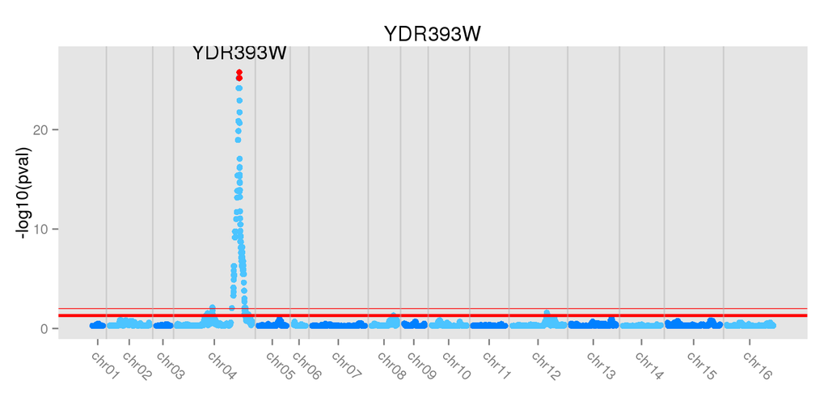

## QTL Inspection

To explore the QTL in a little more detail, we inspect the data itself to confirm that the QTL prediction is plausible in context of the raw data. We will focus on the most significant QTL peak.

### In-group vs. Out-group correlation

First, we expect that if we split the data by genotype at the QTL locus, there should be an increase in correlation between 3’-UTR profiles within the genotypes compared to across the genotypes.

Below I report peason correlation.

-Within Genotype 1: 0.7766889 -Within Genotype 2: 0.6222948 -Between 1-2:0.235735 -Between 2-1:0.2506568

As expected, correlation is higher within the genotype groups than between them.

Genome-wide, for every QTL the correlations within a genotype have a similar pattern (higher within than between):

One-sided Welch two sample t-test soundly rejects null hypothesis at p-val = < 2.2e-16.

This is clear in boxplot of all pairwise correlations in and between genotypes at a QTL

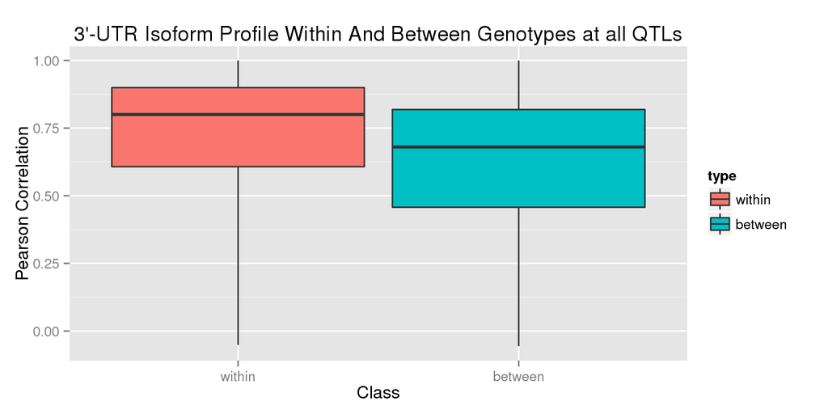

Second, we visualize the 3’-UTR profiles as a heatmap. The side bar shows the allele state at the most significant genetic marker.

In this example it is clear that there is a difference in the 3’-UTR profiles given genotype. Profiles for genotypes with the Y allele are missing prominent peaks in the profiles of this gene with the Y allele.

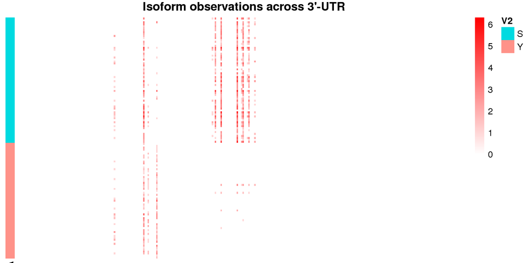